# Ajustes de modelo por máxima verossimilhança

Paulo Inácio Prado  
2026-10-02

# Ajuste de regressão linear simples por máxima verossimilhança

## Preparação

Neste roteiro, usaremos um conjunto de dados com o número de espécies de formigas registradas em fragmentos de vegetação de diferentes tamanhos na Califórnia (Suarez et al. 1998). Usaremos esses dados para ajustar um modelo para a relação entre a área de cada fragmento e o número de espécies amostradas neles.

Carregue os pacotes necessários e os dados, que estão disponíveis no material suplementar de Ohyama *et al.* (2021):

```r
library(sads)
library(bbmle)
```

```r
## todos os conjuntos de dados compilados por Ohyama et al
raw <- read.csv("https://github.com/piLaboratory/bie5781/raw/master/data/jbi14149-sup-0003-appendixs3.csv")
## Seleciona dados do estudo de Suarez et al
suarez <- raw[raw$Study_ID=="23", c("Island_area", "Species.Richness")]
```

## Ajuste de modelos

Um dos primeiros modelos propostos para descrever a relação entre a área de uma ilha ou de um fragmento de hábitat ($A$) e o número de espécies que essa área abriga ($S$) é a função potência:

$$S \, = \, \alpha A^{\beta_1}$$

Tomando o logaritmo dos dois lados dessa equação, temos uma função linear:

$$\ln S \, = \, \beta_0 + \beta_1 \ln A$$

Em que $\beta_0= \ln \alpha$. Assim, podemos avaliar se esse modelo se aproxima da relação observada com uma regressão linear simples:

$$\begin{align}
\ln S_i &\sim \text{Normal}(\mu_i, \sigma) \\
\mu_i & = \beta_0 + \beta_1 \ln A_i
\end{align}$$

De fato, a relação espécie-área parece linear em escala logarítmica:

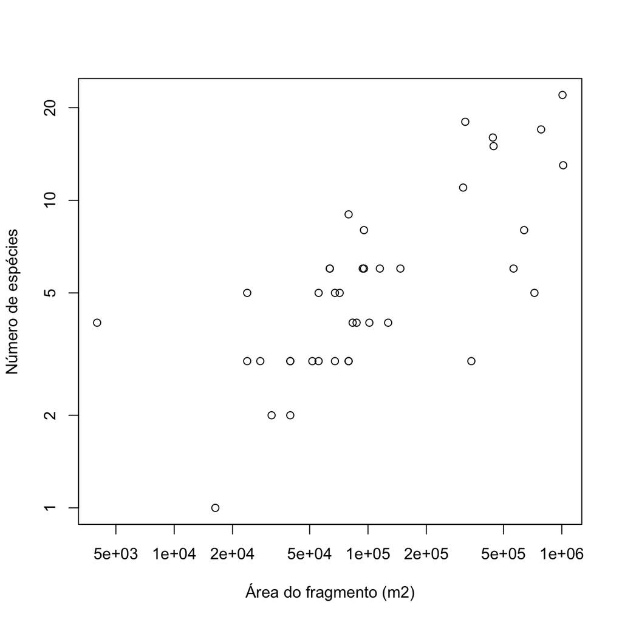

```r
plot(Species.Richness ~ Island_area, data= suarez,
     xlab = "Área do fragmento (m2)", ylab = "Número de espécies", log="xy")
```

Usaremos o método da máxima verossimilhança (MV) para ajustar o modelo de regressão linear aos dados e, depois, compararemos os resultados com o ajuste por mínimos quadrados (MQ).

### Método da máxima verossimilhança

Para fazer o ajuste por MV, usaremos uma rotina computacional de otimização para encontrar os valores dos parâmetros $\beta_0$, $\beta_1$ e $\sigma$ que minimizam a **função de log-verossimilhança negativa**. Lembrando que a função de **verossimilhança** é o produto das probabilidades atribuídas pelo modelo a cada observação, dados valores dos parâmetros:

$$\mathcal{L}_y(\theta)~ = ~\prod_{i=1}^{n} p(y_i \mid \theta)$$

A função de **log-verossimilhança negativa** é igual ao negativo do logaritmo desse produto:

$$L_y(\theta) ~=~ -\ln \mathcal{L}_y(\theta) ~=~-\sum_{i=1}^{n} \ln p(y_i \mid \theta)$$

Usamos o logaritmo porque a função de verossimilhança é um produto de densidades probabilísticas, que em geral são números menores que um[^1]. Com algumas dezenas de observações, esse produto fica tão próximo de zero que os computadores em geral não têm precisão para lidar com ele. Quando calculamos o logaritmo de um número positivo mas próximo de zero, temos um número de magnitude trabalhável. Por exemplo, confira o logaritmo de um trilionésimo:

```r
log(1e-12)
```

Essa transformação tem outras vantagens de cálculo. O logaritmo de um produto se torna uma soma, o que é conveniente[^2]. Além disso, as rotinas computacionais de otimização em geral buscam mínimos de funções (ou se dão melhor com eles), e não máximos. Por isso multiplicamos o valor da log-verossimilhança por menos um ($-1$), e o seu máximo torna-se um mínimo.

#### Definindo a função de log-verossimilhança negativa no R

Em resumo, temos a **log-verossimilhança negativa**. Para fazer um ajuste, precisaremos então buscar os valores dos parâmetros do modelo que **minimizam** esta função. Começamos criando uma função no R que calcula essa função para os dados:

```r
LL1 <- function(beta0, beta1, sigma){
    mu <- beta0 + beta1*log(suarez$Island_area)
    -sum( dnorm(x = log(suarez$Species.Richness), mean = mu, sd = sigma, log=TRUE) )
    }
```

O comando acima cria um objeto da classe `function` que tem como argumentos os três parâmetros do modelo linear. A primeira linha da função calcula o valor esperado $\mu$, usando quaisquer valores de $\{\beta_0,\beta_1\}$ que você fornecer à função. A segunda linha calcula o valor da função de densidade normal para cada valor de $\ln S$, toma o logaritmo dessas densidades e soma todos eles. Por exemplo, verifique a log-verossimilhança negativa desse modelo para esses dados, usando $\beta_0 = 1, \beta_1 = 1$ e $\sigma = 1$, é

```r
LL1(beta0 = 1, beta1 = 1, sigma =1)
```

#### Encontrando o mínimo da função de log-verossimilhança

Agora chamamos uma rotina de otimização para minimizar a função definida acima. Usaremos a função `mle2`, do pacote *bbmle*, que serve de interface para as rotinas de otimização. A função `mle2` do R foi adaptada ao problema específico de minimizar computacionalmente funções de log-verossimilhança negativa. Você encontra mais detalhes na página de ajuda de `mle2` e também na [vinheta do pacote bbmle](https://cran.r-project.org/web/packages/bbmle/vignettes/mle2.pdf).

Execute a otimização e guarde o ajuste em um objeto chamado `ml1`. Note que a função de otimização necessita de **valores iniciais** dos parâmetros a partir dos quais começa a investigar diferentes combinações de valores, até encontrar o mínimo da função (se tudo der certo!). Estes valores iniciais são fornecidos como uma lista, que usa os nomes dos parâmetros definidos na função de log-verossimilhança negativa. Como sabemos que esta otimização é simples, chutamos valores quaisquer. Mas, em muitos casos, é importante usar bons valores iniciais, e há algumas maneiras de buscar chutes educados.

```r
ml1 <- mle2(LL1, start = list(beta0 = 0, beta1 = 0.1, sigma = 0.5))
```

Esse objeto tem os métodos usuais das classes de modelos estatísticos ajustados no R. Por exemplo, você obtém um resumo do ajuste com:

```r
summary(ml1)
```

Os valores estimados dos parâmetros são as estimativas de máxima verossimilhança (**MLE**). Guarde-as em um objeto separado:

```r
(ml1.cf <- coef(ml1))
```

E então você pode usar essas estimativas para desenhar a reta de regressão ajustada:

```r
plot(log(Species.Richness) ~ log(Island_area), data= suarez,
     xlab = "ln área do fragmento (m2)", ylab = "ln Número de espécies")
abline(coef = ml1.cf, col ="blue")
```

[output not shown]

### Inferência: perfis de verossimilhança

Quão precisas são as MLE que obtivemos com esse ajuste? Podemos verificar isso com **perfis de verossimilhança**. Para modelos ajustados com a função `mle2`, o pacote [sads](https://cran.r-project.org/web/packages/sads/index.html) tem a função `plotprofmle`, que desenha esses perfis:

```r
if(!require(sads)){install.packages("sads"); library(sads)}
ml1.p <- profile(ml1, alpha =0.05) ## calcula o perfil
## Uma janela gráfica para 3 gráficos
par(mfrow = c(1,3))
## Os gráficos
plotprofmle(ml1.p, ylim = c(0,3))
## volta a janela para 1 gráfico
par(mfrow=c(1,1))
```

[output not shown]

```r
likelregions(ml1.p)
```

O parâmetro de importância teórica é o coeficiente da função de potência, $\beta_1$. O intervalo de plausibilidade é parecido com a faixa de valores desse coeficiente registrada em outros sistemas de fragmentos continentais (veja, por exemplo, a Fig. 2 de Ohyama et al 2021).

### Método dos mínimos quadrados

O método dos mínimos quadrados (MQ) é a solução de máxima verossimilhança para uma regressão linear Gaussiana simples. Você pode verificar isso ajustando o mesmo modelo com a função `lm`, que usa o MQ:

```r
## Ajusta o mesmo modelo por MQ
ls1 <- lm(log(Species.Richness) ~ log(Island_area), data= suarez)
```

e então comparando os coeficientes dos dois ajustes:

```r
(ls1.cf <- coef(ls1)) # MQ
ml1.cf[1:2]
```

Em casos simples como esse, os limites do intervalo de confiança frequentista também ficam próximos dos limites do intervalo de plausibilidade:

```r
confint(ls1)
likelregions(ml1.p)
```

Há, porém, uma diferença sistemática. A MLE da variância (parâmetro $\sigma$ ao quadrado) é a média dos quadrados dos resíduos:

$$\widehat{\sigma²}=\frac{\sum(y_i-\hat{y})^2}{n}$$

Você pode verificar isso:

```r
## valores previstos:
ml1.yhat <- ml1.cf[1] + ml1.cf[2]*log(suarez$Island_area)
## resíduos
ml1.res <- log(suarez$Species.Richness) - ml1.yhat
## Raiz da média dos quadrados dos resíduos
sum (ml1.res^2) / nrow(suarez)
## compare com a MLE
ml1.cf[3]^2
```

O método de MQ estima a variância da normal do modelo ($\sigma^2$) com uma correção de viés para amostras pequenas ($n-2$):

$$\widehat{\sigma^2}=\frac{\sum(y_i-\hat{y})^2}{n-2}$$

O que você também pode verificar:

```r
## valores previstos:
ls1.yhat <- ls1.cf[1] + ls1.cf[2]*log(suarez$Island_area)
## resíduos
ls1.res <- log(suarez$Species.Richness) - ls1.yhat
## Raiz da soma dos quadrados dos resíduos dividida por n-2
sum (ls1.res^2) / (nrow(suarez)-2)
## compare com o valor estimado pelo ajuste
summary(ls1)$sigma^2
```

# Propriedades dos MLE

Sob certas premissas[^4], os estimadores de máxima verossimilhança têm várias propriedades de um [estimador](http://en.wikipedia.org/wiki/Estimator) ideal. Para demonstrar essas propriedades das MLE, vamos fazer algumas simulações no R, com os seguintes passos:

1. geramos um grande número de amostras de uma distribuição conhecida, com valores conhecidos dos parâmetros;
2. obtemos as MLE para cada uma das amostras simuladas;
3. construímos gráficos da distribuição das MLE para analisar o seu comportamento.

## Consistência

A [consistência](http://en.wikipedia.org/wiki/Consistent_estimator) é a propriedade de convergir em probabilidade para o valor do parâmetro com o aumento da amostra. Para verificar a consistência, utilizaremos a MLE do desvio-padrão da Gaussiana, que é sabidamente enviesada:

$$\widehat{\sigma} = \left[ \frac{1}{n} \sum_{i=1}^n (x_i - \bar{x})^2 \right] ^{(1/2)}$$

Primeiramente, criaremos uma função para obter essa MLE:

```r
sd.mle = function(x)  sqrt( (1/length(x)) * sum( (x - mean(x))^2 ) )
```

Esse estimador será aplicado a amostras de tamanhos crescentes da distribuição Gaussiana com média 100 e desvio-padrão 5.

Gerando a distribuição das MLE para amostras de tamanho 10:

```r
set.seed(42)                                        # sementes de n aleatórios
samp10 = sort(rep(1:1000, 10))                      # identificador das 1000 amostras de tamanho 10
vals10 = rnorm(1000*10, mean=100, sd=5)             # valores das observações
dens10 = density( tapply(vals10, samp10, sd.mle) )  # obtendo a MLE para cada amostra e a densidade empírica
dens10$y = dens10$y/ max(dens10$y)                  # convertendo o valor de densidade para valor relativo ao máximo
plot( dens10, type="l", xlab="Valor estimado",
        ylab="Densidade" ,main="")                  # gráfico da distribuição das MLE
abline(v = 5, col="red", lwd=2 )                    # posição do valor do parâmetro no gráfico
```

[output not shown]

Gerando a distribuição das MLE para amostras de tamanho 100:

```r
samp100 = sort(rep(1:1000, 100))
vals100 = rnorm(1000*100, mean=100, sd=5)
dens100 = density( tapply(vals100, samp100, sd.mle) )
dens100$y = dens100$y/ max(dens100$y)
lines( dens100, col="blue" )
```

## Eficiência assintótica

A [eficiência assintótica](http://en.wikipedia.org/wiki/Efficient_estimator) afirma que as MLE terão a menor variância possível à medida que o tamanho da amostra aumenta.

Vamos comparar a variância das MLE do desvio-padrão obtidas acima (nossa função `sd.mle`) com a dos valores do estimador tradicional, calculados para as mesmas amostras (a função `sd` do R):

```r
## Amostras de tamanho 10
var( tapply(vals10, samp10, sd.mle) )
var( tapply(vals10, samp10, sd) )
## Amostras de tamanho 100
var( tapply(vals100, samp100, sd.mle) )
var( tapply(vals100, samp100, sd) )
```

## Normalidade assintótica

Esta é a propriedade de [normalidade assintótica](http://en.wikipedia.org/wiki/Asymptotic_normality), que garante que a distribuição das MLE[^5] se aproxima de uma distribuição normal com o aumento do tamanho da amostra. Ela pode ser entendida como uma extensão do Teorema Central do Limite para todas as MLE.

A melhor forma de investigar a aproximação assintótica da distribuição Gaussiana é com o gráfico quantil-quantil:

```r
par(mfrow=c(2,1))
qqnorm( tapply(vals10, samp10, sd.mle),
          main="MLE do desvio-padrão, N=10" )
qqline( tapply(vals10, samp10, sd.mle) )
qqnorm( tapply(vals100, samp100, sd.mle),
          main="MLE do desvio-padrão, N=100")
qqline( tapply(vals100, samp100, sd.mle) )
par(mfrow=c(1,1))
```

[output not shown]

## Invariância

A propriedade de invariância diz que, se $\hat{\theta}$ é a MLE de um parâmetro $\theta$, então, para qualquer função [monotônica](https://en.wikipedia.org/wiki/Monotonic_function) de $g$, $g(\hat{\theta})$ é a MLE de $g(\theta)$. Em outras palavras, se estimamos um parâmetro por máxima verossimilhança, obtemos de graça as MLE de qualquer transformação monotônica dele, sem precisar refazer o ajuste[^6].

Por exemplo, a MLE da variância de uma Gaussiana é a média dos quadrados dos desvios em relação à média:

$$\widehat{\sigma^2} = \frac{1}{n} \sum_{i=1}^n (x_i - \bar{x})^2$$

Pela invariância, a raiz quadrada dessa estimativa deve ser a MLE do desvio-padrão, que usamos nas seções anteriores. Vamos conferir com a primeira das amostras simuladas de tamanho 10:

```r
var.mle = function(x) mean( (x - mean(x))^2 )   # MLE da variância
x1 = vals10[samp10 == 1]                        # primeira amostra de tamanho 10
sqrt( var.mle(x1) )                             # raiz da MLE da variância
sd.mle(x1)                                      # MLE do desvio-padrão
```

Neste caso, a igualdade é óbvia pelas próprias fórmulas. Mas a propriedade vale também quando não temos fórmulas e encontramos as MLE numericamente. Vamos ajustar uma Gaussiana à mesma amostra com a função `mle2`, de duas formas: estimando o desvio-padrão e estimando a variância.

```r
## Log-verossimilhança negativa com o desvio-padrão como parâmetro
LL.sd = function(mu, sigma) -sum( dnorm(x1, mean = mu, sd = sigma, log = TRUE) )
## Log-verossimilhança negativa com a variância como parâmetro
LL.var = function(mu, v) -sum( dnorm(x1, mean = mu, sd = sqrt(v), log = TRUE) )

m.sd  = mle2(LL.sd,  start = list(mu = 100, sigma = 5),
             method = "L-BFGS-B", lower = c(mu = -Inf, sigma = 1e-6))
m.var = mle2(LL.var, start = list(mu = 100, v = 25),
             method = "L-BFGS-B", lower = c(mu = -Inf, v = 1e-6))

coef(m.sd)["sigma"]       # MLE do desvio-padrão
sqrt( coef(m.var)["v"] )  # raiz da MLE da variância
```

### Nem toda propriedade de um estimador é invariante

Para entender por que a invariância é uma propriedade valiosa, vale ver uma propriedade que **não** se mantém sob transformações: as correções para vieses amostrais.

O estimador tradicional da variância (que não é um MLE), tem uma correção para viés em amostras pequenas, que divide por $n-1$: .

$$\widehat{s^2} = \frac{ \sum_{i=1}^n (x_i - \bar{x})^2 }{ n - 1 }$$

A redução do viés pode ser comprovada com uma simulação:

```r
var.trad10 = tapply( vals10, samp10, var)    # estimativas com correção de viés da variância de amostras de tamanho 10
plot( density(var.trad10), type="l" )        # distribuição das estimativas
abline( v = mean(var.trad10) )               # média das estimativas
abline( v = 5^2, col="red" )                 # valor do parâmetro
```

[output not shown]

Mas a raiz quadrada desse estimador, que é o estimador tradicional do desvio-padrão (a função `sd` do R), é viesada:

$$\widehat{s} = \sqrt{ \widehat{s^2}} \ = \ \sqrt{ \frac{ \sum_{i=1}^n (x_i - \bar{x})^2 }{ n - 1 } }$$

Verifique isso repetindo a avaliação de viés feita antes para a variância:

```r
sd.trad10 =  tapply(vals10, samp10, sd )
plot(density(sd.trad10), type="l")
abline( v = mean(sd.trad10) )
abline( v = 5, col="red" )
```

[output not shown]

Ou seja, a ausência de viés se perde com uma simples transformação do parâmetro. As MLE também não garantem ausência de viés para amostras pequenas, como vimos na seção sobre consistência. O que elas garantem pé que este viés se reduz com o aumento da amostra, e também a invariância.

# Especificando o modelo com o pacote rethinking

Em nosso curso usamos uma notação para descrição dos modelos como o processo que gera os dados:

$$\begin{align}
\ln S_i &\sim \text{Normal}(\mu_i, \sigma) \\
\mu_i & = \beta_{0} + \beta_1 \ln A_i
\end{align}$$

Já na primeira parte deste tutorial, tivemos que traduzir essa descrição para duas outras sintaxes dentro do R:

1. Escrever uma função que retorna a log-verossimilhança negativa (`LL1`), que então passamos a um otimizador.
2. Ajustar o modelo com a função `lm` , que usa a sintaxe de modelos do R (`lm(log(Species.Richness) ~ log(Island_area), data = suarez)`)

O pacote **rethinking** (McElreath 2020) permite especificar o modelo no R exatamente como na notação que usamos nas aulas. O pacote se encarrega de montar a função de verossimilhança e de otimizá-la.

## Instalação

O rethinking não está no CRAN. Para instalá-lo a partir do GitHub:

```r
install.packages(c("coda", "mvtnorm", "devtools", "loo", "dagitty", "shape"))
devtools::install_github("rmcelreath/rethinking")
```

Algumas funções do pacote, como `ulam`, dependem do Stan, mas a função que usaremos aqui (`quap`) funciona sem ele.

## Especificação do modelo

Primeiro, carregue o pacote e prepare uma tabela apenas com as variáveis do modelo, já na escala logarítmica:

```r
library(rethinking)
dados <- data.frame(lnS = log(suarez$Species.Richness),
                    lnA = log(suarez$Island_area))
```

O modelo é escrito como uma lista de fórmulas, criada com a função `alist`. Cada linha da lista corresponde a uma linha das equações do modelo:

```r
modelo <- alist(
    lnS ~ dnorm(mu, sigma),   # ln S_i ~ Normal(mu_i, sigma)
    mu <- b0 + b1 * lnA       # mu_i = beta_0 + beta_1 ln A_i
)
```

Repare na diferença entre os dois símbolos usados:

- **`~`** indica uma relação **estocástica**: a variável à esquerda é uma variável aleatória, que segue a distribuição de probabilidade à direita. É a primeira linha do modelo, que diz que $\ln S$ segue uma distribuição Normal. A distribuição é indicada pela função de densidade correspondente do R (`dnorm`).
- **`<-`** indica uma relação **determinística**: o valor à esquerda é calculado exatamente a partir dos valores à direita. É a segunda linha do modelo, que diz que a média $\mu$ é uma função linear de $\ln A$.

Os nomes usados na lista são de três tipos. Os que estão na tabela de dados (`lnS` e `lnA`) são as **variáveis**. Os que são definidos por `<-` (`mu`) são **quantidades derivadas**. Todos os demais (`b0`, `b1` e `sigma`) são os **parâmetros** a serem estimados.

## Ajuste do modelo

O ajuste é feito com a função `quap`, que procura os valores dos parâmetros que maximizam a verossimilhança, usando as mesmas rotinas de otimização que a função `mle2`. Como no `mle2`, é preciso fornecer valores iniciais para os parâmetros:

```r
ml1.r <- quap(modelo, data = dados,
              start = list(b0 = 0, b1 = 0.1, sigma = 0.5))
```

O resumo do ajuste é obtido com a função `precis`:

```r
precis(ml1.r, prob = 0.95)
```

Compare as estimativas com as que obtivemos com o `mle2` e com o `lm`:

```r
coef(ml1.r)
ml1.cf
ls1.cf
```

As estimativas devem ser praticamente iguais, pois os três ajustes maximizam a mesma função de verossimilhança. Pequenas diferenças nas últimas casas decimais vêm do critério de parada da otimização.

Os intervalos mostrados por `precis` não são, porém, os intervalos de plausibilidade que obtivemos com os perfis de verossimilhança. A função `quap` aproxima a superfície de log-verossimilhança em torno do máximo por uma função quadrática, o que equivale a supor que a distribuição das estimativas é Normal (lembre-se da propriedade de normalidade assintótica dos MLE, que vimos na seção anterior). Os intervalos são calculados a partir dessa aproximação. Por isso, eles podem diferir dos intervalos calculados com `likelregions`, principalmente quando a amostra é pequena ou quando o perfil de verossimilhança é assimétrico, o que é comum para o parâmetro $\sigma$:

```r
precis(ml1.r, prob = 0.95)
likelregions(ml1.p)
```

## Evitando valores negativos de $\sigma$

O desvio-padrão $\sigma$ só pode assumir valores positivos, mas a rotina de otimização não sabe disso. Se ela tentar valores negativos de $\sigma$ durante a busca, você verá mensagens de erro ou avisos. Uma solução é estimar o logaritmo de $\sigma$, que pode assumir qualquer valor real, e indicar a transformação diretamente na especificação do modelo:

```r
modelo.log <- alist(
    lnS ~ dnorm(mu, exp(log_sigma)),
    mu <- b0 + b1 * lnA
)
ml1.r2 <- quap(modelo.log, data = dados,
               start = list(b0 = 0, b1 = 0.1, log_sigma = log(0.5)))
exp(coef(ml1.r2)["log_sigma"])
```

Pela propriedade de invariância dos MLE, a exponencial da estimativa de $\log \sigma$ é a estimativa de máxima verossimilhança de $\sigma$.

## Spoiler: ajustes bayesianos

O pacote rethinking foi criado para o ensino de estatística bayesiana, e a função `quap` também ajusta modelos bayesianos. Veremos esses modelos em outra aula, mas vale adiantar a intuição de por que o nosso ajuste pode ser visto como um caso particular deles.

Em um modelo bayesiano, além da distribuição dos dados, atribuímos a cada parâmetro uma **distribuição a priori**, que expressa o quanto consideramos plausível cada valor do parâmetro antes de olhar para os dados. O resultado do ajuste combina essas duas fontes de informação: a plausibilidade de cada valor dos parâmetros depois de olhar para os dados é proporcional à verossimilhança multiplicada pela distribuição a priori[^7].

Agora imagine que consideramos **todos os valores dos parâmetros igualmente prováveis** antes de olhar para os dados. Nesse caso, a distribuição a priori é a mesma para qualquer valor, e multiplicar a verossimilhança por ela não muda a posição do seu máximo. Os valores mais plausíveis dos parâmetros passam a ser simplesmente os que maximizam a verossimilhança, ou seja, os MLE.

É exatamente isso que acontece quando não indicamos distribuições a priori no modelo: a função `quap` trata todos os valores dos parâmetros como igualmente prováveis e encontra os mesmos valores que obtivemos com o `mle2`. Nesse caso, é obrigatório fornecer os valores iniciais com o argumento `start` para a função `quap`.

# Referências

- McElreath, R. (2020). Statistical Rethinking: A Bayesian Course with Examples in R and Stan. 2nd ed. CRC Press.
- Ohyama, L., Holt, R. D., Matthews, T. J., & Lucky, A. (2021). The species–area relationship in ant ecology. Journal of Biogeography, 48(8), 1824-1841.
- Stigler, S. M. (2007). The epic story of maximum likelihood. Statistical Science, 598-620.
- Suarez, A. V., Bolger, D. T., & Case, T. J. (1998). Effects of fragmentation and invasion on native ant communities in coastal southern California. Ecology, 79(6), 2041-2056.
- Zehna, P. W. (1966). Invariance of maximum likelihood estimators. Annals of Mathematical Statistics, 37(3), 744.
[^1]: As probabilidades sempre são menores ou iguais a um. Densidades probabilísticas podem ser maiores do que um. Mas mesmos nestes casos um produto de muitos números acima d eum pode resultar em um número muito grande, o que também é um problema para cálculos com computador.
[^2]: Por essa propriedade, logaritmos foram muito usados para cálculos multiplicativos, antes que houvesse calculadoras.
[^3]: Este critério de diferença de até 2 unidades de log-verossimilhança é arbitrário. A princípio, não há nenhum problema em usar outro, seja menor (mais rigoroso) ou maior (mais permissivo), desde que ele seja explicitado.
[^4]: Stigler (2007) faz uma análise histórica aprofundada do método de máxima verossimilhança e dos MLEs. Uma das conclusões é que as propriedades dos MLEs não são totalmente generalizáveis. Ainda assim, aplicam-se a uma ampla classe de modelos, e por isso continuam muito úteis.
[^5]: Esta é a distribuição teórica das MLE que seriam obtidas se os dados fossem coletados e o modelo ajustado a eles muitas vezes.
[^6]: Há generalizações para outras transformações (Zehna, 1966), mas para fins didáticos ficamos apenas com transformações monotônicas, que são terreno mais seguro.
[^7]: Não se preocupe se não entender isso ainda. Explicaremos nas próximas aulas.